# Household Power Consumption Prediction and Model Evaluation

### Prepare for dataset

```python
from pyspark.sql import SparkSession
import pandas as pd
spark = SparkSession.builder.appName('ml-household').getOrCreate()
df = spark.read.csv('hdfs://namenode/household.csv', header = True, inferSchema = True)
df.printSchema()
```

```
root
 |-- Date: string (nullable = true)
 |-- Time: string (nullable = true)
 |-- Global_active_power: string (nullable = true)
 |-- Global_reactive_power: string (nullable = true)
 |-- Voltage: string (nullable = true)
 |-- Global_intensity: string (nullable = true)
 |-- Sub_metering_1: string (nullable = true)
 |-- Sub_metering_2: string (nullable = true)
 |-- Sub_metering_3: integer (nullable = true)
```

### Create copies for date/time columns

```python
df.head
df = df.toPandas()
df[['Day', 'Month', 'Year']] = df.Date.str.split("/", expand = True)
type(df)
```

```
pandas.core.frame.DataFrame
```

### Remove repeated columns

```python
df = df.drop(['Date', 'Time'], axis = 1)
df.head()
print(type(df))
```

```
<class 'pandas.core.frame.DataFrame'>
```

### Perform data cleansing

```python
import numpy as np
print(type(df))
df = df.replace('NA', np.nan)
df.isna().any()
```

```
<class 'pandas.core.frame.DataFrame'>
```

```
Global_active_power      False
Global_reactive_power    False
Voltage                  False
Global_intensity         False
Sub_metering_1           False
Sub_metering_2           False
Sub_metering_3            True
Day                      False
Month                    False
Year                     False
dtype: bool
```

Replace records with 'NA' by NaN in the numpy library.

```python
df.Sub_metering_3 = df.Sub_metering_3.replace(np.nan, df.Sub_metering_3.mean())
df.Sub_metering_3
```

```
0          17.0
1          16.0
2          17.0
3          17.0
4          17.0
           ...
1048570     0.0
1048571     0.0
1048572     0.0
1048573     0.0
1048574     0.0
Name: Sub_metering_3, Length: 1048575, dtype: float64
```

Replace records with NaN in numpy by the mean value of the "Sub_metering_3" column.

```python
df.isna().any()
```

```
Global_active_power      False
Global_reactive_power    False
Voltage                  False
Global_intensity         False
Sub_metering_1           False
Sub_metering_2           False
Sub_metering_3           False
Day                      False
Month                    False
Year                     False
dtype: bool
```

Detect missing values.

```python
df.info()
```

```
<class 'pandas.core.frame.DataFrame'>
RangeIndex: 1048575 entries, 0 to 1048574
Data columns (total 10 columns):
 #   Column                 Non-Null Count    Dtype
---  ------                 --------------    -----
 0   Global_active_power    1048575 non-null  object
 1   Global_reactive_power  1048575 non-null  object
 2   Voltage                1048575 non-null  object
 3   Global_intensity       1048575 non-null  object
 4   Sub_metering_1         1048575 non-null  object
 5   Sub_metering_2         1048575 non-null  object
 6   Sub_metering_3         1048575 non-null  float64
 7   Day                    1048575 non-null  object
 8   Month                  1048575 non-null  object
 9   Year                   1048575 non-null  object
dtypes: float64(1), object(9)
memory usage: 80.0+ MB
```

```python
df = df.replace('?', np.nan)
df.isna().any()
```

```
Global_active_power       True
Global_reactive_power     True
Voltage                   True
Global_intensity          True
Sub_metering_1            True
Sub_metering_2            True
Sub_metering_3           False
Day                      False
Month                    False
Year                     False
dtype: bool
```

Replace records with '?' by NaN in the numpy library.

```python
df = df.astype('float64')
```

```python
df.Global_active_power = df.Global_active_power.replace(np.nan, df.Global_active_power.mean())
df.Global_active_power
```

```
0          4.216
1          5.360
2          5.374
3          5.388
4          3.666
           ...
1048570    0.426
1048571    0.424
1048572    0.422
1048573    0.422
1048574    0.422
Name: Global_active_power, Length: 1048575, dtype: float64
```

Replace records with NaN in numpy by the mean value of the "Global_active_power" column.

```python
df.Global_reactive_power = df.Global_reactive_power.replace(np.nan, df.Global_reactive_power.mean())
df.Global_reactive_power
```

```
0          0.418
1          0.436
2          0.498
3          0.502
4          0.528
           ...
1048570    0.076
1048571    0.076
1048572    0.076
1048573    0.078
1048574    0.078
Name: Global_reactive_power, Length: 1048575, dtype: float64
```

Replace records with NaN in numpy by the mean value of the "Global_reactive_power" column.

```python
df.Voltage = df.Voltage.replace(np.nan, df.Voltage.mean())
df.Voltage
```

```
0          234.84
1          233.63
2          233.29
3          233.74
4          235.68
            ...
1048570    242.27
1048571    242.10
1048572    241.73
1048573    242.56
1048574    242.61
Name: Voltage, Length: 1048575, dtype: float64
```

Replace records with NaN in numpy by the mean value of the "Voltage" column.

```python
df.Global_intensity = df.Global_intensity.replace(np.nan, df.Global_intensity.mean())
df.Global_intensity
```

```
0          18.4
1          23.0
2          23.0
3          23.0
4          15.8
           ...
1048570     1.8
1048571     1.8
1048572     1.8
1048573     1.8
1048574     1.8
Name: Global_intensity, Length: 1048575, dtype: float64
```

Replace records with NaN in numpy by the mean value of the "Global_intensity" column.

```python
df.Sub_metering_1 = df.Sub_metering_1.replace(np.nan, df.Sub_metering_1.mean())
df.Sub_metering_1
```

```
0          0.0
1          0.0
2          0.0
3          0.0
4          0.0
          ...
1048570    0.0
1048571    0.0
1048572    0.0
1048573    0.0
1048574    0.0
Name: Sub_metering_1, Length: 1048575, dtype: float64
```

Replace records with NaN in numpy by the mean value of the "Sub_metering_1" column.

```python
df.Sub_metering_2 = df.Sub_metering_2.replace(np.nan, df.Sub_metering_2.mean())
df.Sub_metering_2
```

```
0          1.0
1          1.0
2          2.0
3          1.0
4          1.0
          ...
1048570    0.0
1048571    0.0
1048572    0.0
1048573    0.0
1048574    0.0
Name: Sub_metering_2, Length: 1048575, dtype: float64
```

Replace records with NaN in numpy by the mean value of the "Sub_metering_2" column.

```python
df.isna().any()
```

```
Global_active_power      False
Global_reactive_power    False
Voltage                  False
Global_intensity         False
Sub_metering_1           False
Sub_metering_2           False
Sub_metering_3           False
Day                      False
Month                    False
Year                     False
dtype: bool
```

```python
df.head()
```

|  | Global_active_power | Global_reactive_power | Voltage | Global_intensity | Sub_metering_1 | Sub_metering_2 | Sub_metering_3 | Day | Month | Year |
| --- | --- | --- | --- | --- | --- | --- | --- | --- | --- | --- |
| 0 | 4.216 | 0.418 | 234.84 | 18.4 | 0.0 | 1.0 | 17.0 | 16.0 | 12.0 | 2006.0 |
| 1 | 5.360 | 0.436 | 233.63 | 23.0 | 0.0 | 1.0 | 16.0 | 16.0 | 12.0 | 2006.0 |
| 2 | 5.374 | 0.498 | 233.29 | 23.0 | 0.0 | 2.0 | 17.0 | 16.0 | 12.0 | 2006.0 |
| 3 | 5.388 | 0.502 | 233.74 | 23.0 | 0.0 | 1.0 | 17.0 | 16.0 | 12.0 | 2006.0 |
| 4 | 3.666 | 0.528 | 235.68 | 15.8 | 0.0 | 1.0 | 17.0 | 16.0 | 12.0 | 2006.0 |

```python
from sklearn.preprocessing import MinMaxScaler
scaler = MinMaxScaler()
columns = df.columns
df = scaler.fit_transform(df)
df = pd.DataFrame(df)
df.columns = columns
df
```

|  | Global_active_power | Global_reactive_power | Voltage | Global_intensity | Sub_metering_1 | Sub_metering_2 | Sub_metering_3 | Day | Month | Year |
| --- | --- | --- | --- | --- | --- | --- | --- | --- | --- | --- |
| 0 | 0.390787 | 0.300719 | 0.396161 | 0.393939 | 0.0 | 0.012821 | 0.548387 | 0.5 | 1.0 | 0.0 |
| 1 | 0.498773 | 0.313669 | 0.353927 | 0.493506 | 0.0 | 0.012821 | 0.516129 | 0.5 | 1.0 | 0.0 |
| 2 | 0.500094 | 0.358273 | 0.342059 | 0.493506 | 0.0 | 0.025641 | 0.548387 | 0.5 | 1.0 | 0.0 |
| 3 | 0.501416 | 0.361151 | 0.357766 | 0.493506 | 0.0 | 0.012821 | 0.548387 | 0.5 | 1.0 | 0.0 |
| 4 | 0.338871 | 0.379856 | 0.425480 | 0.337662 | 0.0 | 0.012821 | 0.548387 | 0.5 | 1.0 | 0.0 |
| ... | ... | ... | ... | ... | ... | ... | ... | ... | ... | ... |
| 1048570 | 0.033038 | 0.054676 | 0.655497 | 0.034632 | 0.0 | 0.000000 | 0.000000 | 0.4 | 1.0 | 1.0 |
| 1048571 | 0.032849 | 0.054676 | 0.649564 | 0.034632 | 0.0 | 0.000000 | 0.000000 | 0.4 | 1.0 | 1.0 |
| 1048572 | 0.032660 | 0.054676 | 0.636649 | 0.034632 | 0.0 | 0.000000 | 0.000000 | 0.4 | 1.0 | 1.0 |
| 1048573 | 0.032660 | 0.056115 | 0.665620 | 0.034632 | 0.0 | 0.000000 | 0.000000 | 0.4 | 1.0 | 1.0 |
| 1048574 | 0.032660 | 0.056115 | 0.667365 | 0.034632 | 0.0 | 0.000000 | 0.000000 | 0.4 | 1.0 | 1.0 |

1048575 rows × 10 columns

I have employed MinMaxScaler to rescale the dataset such that all feature values are in the range [0, 1] as shown in the table above. For each value, MinMaxScaler subtracts the minimum value in the feature and then devides by the range. The range is the difference between the original maximum and original minimum. MinMaxScaler preserves the shape of the original distribution.

### Some descriptions regarding attributes

1. Date: date in format dd/mm/yyyy
2. Time: time in format hh:mm:ss
3. Global active power: household global minute-averaged active power (in kilowatt)
4. Global reactive power: household global minute-averaged active power (in kilowatt)
5. Voltage: minute-averaged voltage (in volt)
6. Gloabl intensity: household global minute-averaged current intensity (in ampere)
7. Sub metering 1: energe sub-metering No.1 (in watt-hour of active energy). It corresponds to the kitchen, containing mainly a diswasher, an oven and a microwave (hot plates are not electric but gas powered).
8. Sub metering 2: energy sub-metering No.2 (in watt-hour of active energy). It corresponds to the laundry room, containing a washing-machine, a tumble-drier, a refrigerator and a light.
9. Sub metering 3: energy sub-metering No.3 (in watt-hour of active energy). It corresponds to an electric water-heater and an air-conditioner.

### Summary statistics for numeric variables

```python
df.describe().transpose()
```

|  | count | mean | std | min | 25% | 50% | 75% | max |
| --- | --- | --- | --- | --- | --- | --- | --- | --- |
| Global_active_power | 1048575.0 | 0.097433 | 0.106414 | 0.0 | 0.020011 | 0.045309 | 0.138380 | 1.0 |
| Global_reactive_power | 1048575.0 | 0.085089 | 0.078628 | 0.0 | 0.000000 | 0.070504 | 0.133813 | 1.0 |
| Voltage | 1048575.0 | 0.574862 | 0.114420 | 0.0 | 0.505759 | 0.583246 | 0.650960 | 1.0 |
| Global_intensity | 1048575.0 | 0.097795 | 0.102908 | 0.0 | 0.021645 | 0.047619 | 0.134199 | 1.0 |
| Sub_metering_1 | 1048575.0 | 0.014718 | 0.078861 | 0.0 | 0.000000 | 0.000000 | 0.000000 | 1.0 |
| Sub_metering_2 | 1048575.0 | 0.018913 | 0.081287 | 0.0 | 0.000000 | 0.000000 | 0.012821 | 1.0 |
| Sub_metering_3 | 1048575.0 | 0.191414 | 0.264337 | 0.0 | 0.000000 | 0.000000 | 0.548387 | 1.0 |
| Day | 1048575.0 | 0.491407 | 0.294021 | 0.0 | 0.233333 | 0.500000 | 0.733333 | 1.0 |
| Month | 1048575.0 | 0.499872 | 0.312662 | 0.0 | 0.272727 | 0.545455 | 0.727273 | 1.0 |
| Year | 1048575.0 | 0.728397 | 0.269299 | 0.0 | 0.500000 | 0.500000 | 1.000000 | 1.0 |

### Correlations

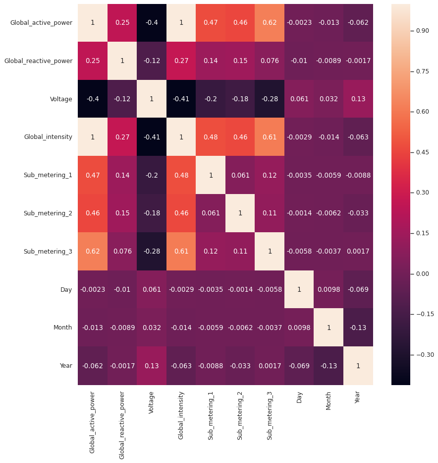

```python
import seaborn as sns; sns.set_theme()
import matplotlib.pyplot as plt
fig, ax = plt.subplots(figsize=(12, 12))
ax = sns.heatmap(df.corr(), annot = True)
```

The correlation coefficient is calculated to measure the statistical relationship or association between attributes of interest that are continuous data.

It's obvious that there aren't many highly correlated independent attributes. However, pairs of attributes give correlation coefficient values so near +/-1 and they suggest there to be a strong correlation.

Therefore, we will keep all of them for the model. However, year, month and day columns are not really useful, we will remove these three columns.

### Line graphs

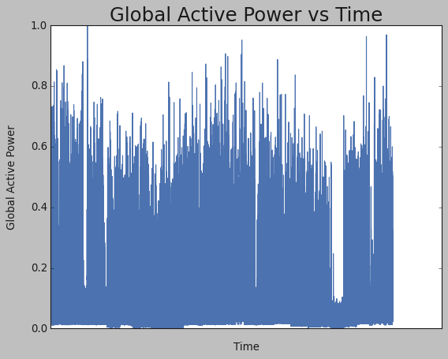

```python
plt.style.use('classic')

plt.plot(df.Global_active_power)
plt.xticks(rotation = 45)

plt.tick_params(
    axis='x',          # changes apply to the x-axis
    which='both',      # both major and minor ticks are affected
    bottom=False,      # ticks along the bottom edge are off
    top=False,         # ticks along the top edge are off
    labelbottom=False) # labels along the bottom edge are off

plt.xlabel("Time", labelpad = 15)
plt.ylabel("Global Active Power", labelpad = 15)
plt.title("Global Active Power vs Time", y = 1.00, fontsize = 22);

plt.show()
```

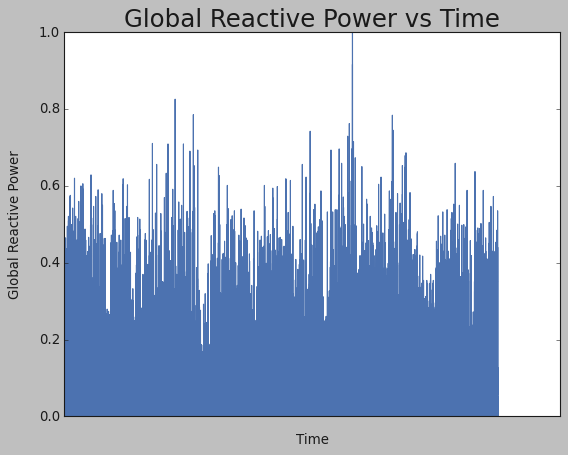

```python
plt.style.use('classic')

plt.plot(df.Global_reactive_power)
plt.xticks(rotation = 45)

plt.tick_params(
    axis='x',          # changes apply to the x-axis
    which='both',      # both major and minor ticks are affected
    bottom=False,      # ticks along the bottom edge are off
    top=False,         # ticks along the top edge are off
    labelbottom=False) # labels along the bottom edge are off

plt.xlabel("Time", labelpad = 15)
plt.ylabel("Global Reactive Power", labelpad = 15)
plt.title("Global Reactive Power vs Time", y = 1.00, fontsize = 22);

plt.show()
```

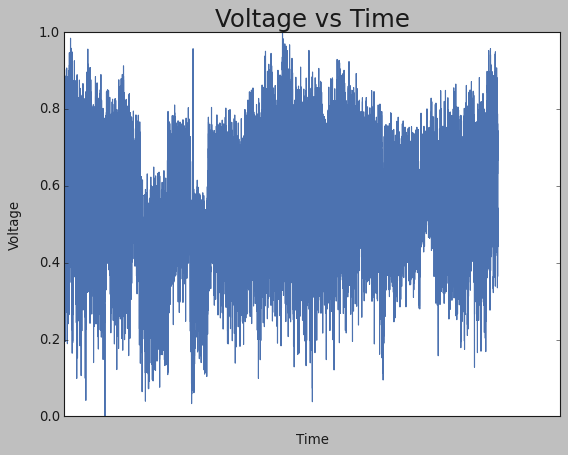

```python
plt.style.use('classic')

plt.plot(df.Voltage)
plt.xticks(rotation = 45)

plt.tick_params(
    axis='x',          # changes apply to the x-axis
    which='both',      # both major and minor ticks are affected
    bottom=False,      # ticks along the bottom edge are off
    top=False,         # ticks along the top edge are off
    labelbottom=False) # labels along the bottom edge are off

plt.xlabel("Time", labelpad = 15)
plt.ylabel("Voltage", labelpad = 15)
plt.title("Voltage vs Time", y = 1.00, fontsize = 22);

plt.show()
```

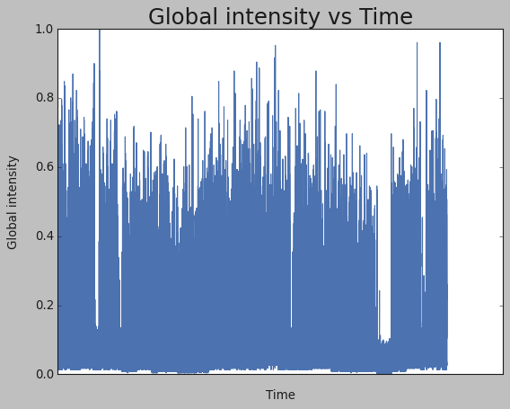

```python
plt.style.use('classic')

plt.plot(df.Global_intensity)
plt.xticks(rotation = 45)

plt.tick_params(
    axis='x',          # changes apply to the x-axis
    which='both',      # both major and minor ticks are affected
    bottom=False,      # ticks along the bottom edge are off
    top=False,         # ticks along the top edge are off
    labelbottom=False) # labels along the bottom edge are off

plt.xlabel("Time", labelpad = 15)
plt.ylabel("Global intensity", labelpad = 15)
plt.title("Global intensity vs Time", y = 1.00, fontsize = 22);

plt.show()
```

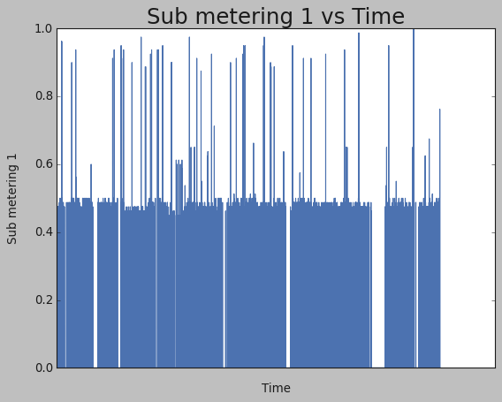

```python
plt.style.use('classic')

plt.plot(df.Sub_metering_1)
plt.xticks(rotation = 45)

plt.tick_params(
    axis='x',          # changes apply to the x-axis
    which='both',      # both major and minor ticks are affected
    bottom=False,      # ticks along the bottom edge are off
    top=False,         # ticks along the top edge are off
    labelbottom=False) # labels along the bottom edge are off

plt.xlabel("Time", labelpad = 15)
plt.ylabel("Sub metering 1", labelpad = 15)
plt.title("Sub metering 1 vs Time", y = 1.00, fontsize = 22);

plt.show()
```

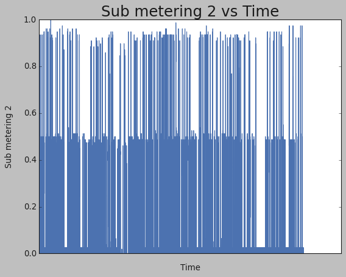

```python
plt.style.use('classic')

plt.plot(df.Sub_metering_2)
plt.xticks(rotation = 45)

plt.tick_params(
    axis='x',          # changes apply to the x-axis
    which='both',      # both major and minor ticks are affected
    bottom=False,      # ticks along the bottom edge are off
    top=False,         # ticks along the top edge are off
    labelbottom=False) # labels along the bottom edge are off

plt.xlabel("Time", labelpad = 15)
plt.ylabel("Sub metering 2", labelpad = 15)
plt.title("Sub metering 2 vs Time", y = 1.00, fontsize = 22);

plt.show()
```

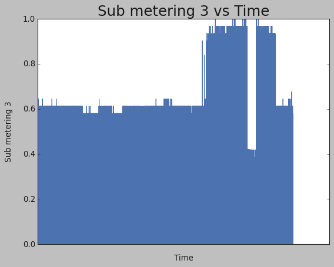

```python
plt.style.use('classic')

plt.plot(df.Sub_metering_3)
plt.xticks(rotation = 45)

plt.tick_params(
    axis='x',          # changes apply to the x-axis
    which='both',      # both major and minor ticks are affected
    bottom=False,      # ticks along the bottom edge are off
    top=False,         # ticks along the top edge are off
    labelbottom=False) # labels along the bottom edge are off

plt.xlabel("Time", labelpad = 15)
plt.ylabel("Sub metering 3", labelpad = 15)
plt.title("Sub metering 3 vs Time", y = 1.00, fontsize = 22);

plt.show()
```

### Boxplots

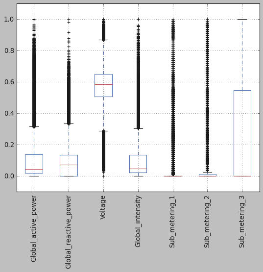

```python
fig, ax = plt.subplots()
boxplot = df.boxplot(column=['Global_active_power', 'Global_reactive_power',
                             'Voltage', 'Global_intensity',
                             'Sub_metering_1', 'Sub_metering_2', 'Sub_metering_3'], rot=90)
ax.set_ylim([-0.1,1.1])
fig = plt.figure(figsize =(12, 7))
```

A boxplot shows the distribution of data in a dataset. It provides information such as "minimum", first quartile (Q1), median, third quartile (Q3) and "maximum". It is useful as it provides a visual sumary of the data, enabling viewers to quickly identify mean values, the dispersion of dataset and signs of skewness.

### Scatter plots

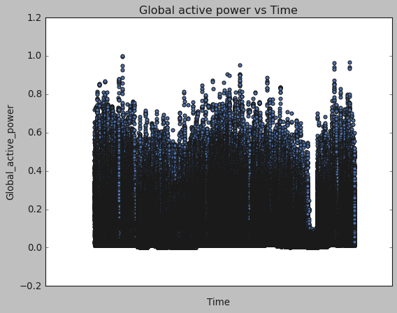

```python
df['Index'] = np.arange(len(df))
y = df['Index']

df.plot.scatter(x='Index', y='Global_active_power', title= "Global active power vs Time")
plt.tick_params(
    axis='x',          # changes apply to the x-axis
    which='both',      # both major and minor ticks are affected
    bottom=False,      # ticks along the bottom edge are off
    top=False,         # ticks along the top edge are off
    labelbottom=False) # labels along the bottom edge are off
plt.xlabel("Time", labelpad = 15)
plt.show(block=True);
```

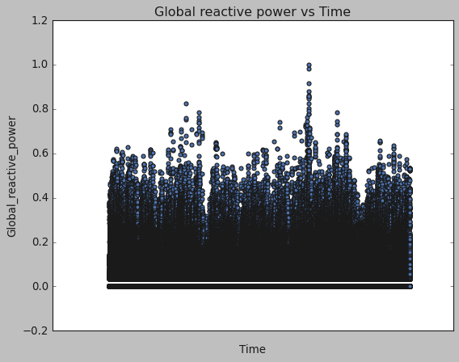

```python
df.plot.scatter(x='Index', y='Global_reactive_power', title= "Global reactive power vs Time")
plt.tick_params(
    axis='x',          # changes apply to the x-axis
    which='both',      # both major and minor ticks are affected
    bottom=False,      # ticks along the bottom edge are off
    top=False,         # ticks along the top edge are off
    labelbottom=False) # labels along the bottom edge are off
plt.xlabel("Time", labelpad = 15)
plt.show(block=True);
```

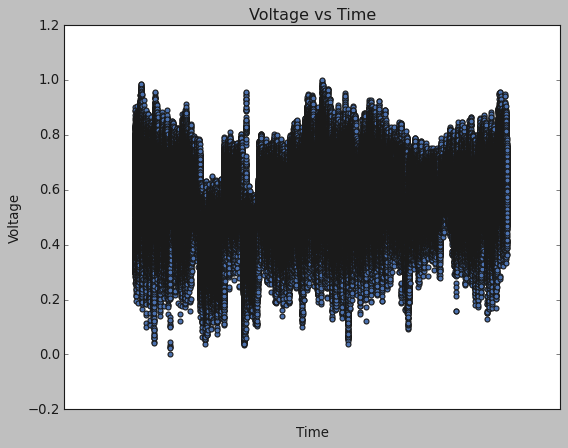

```python
df.plot.scatter(x='Index', y='Voltage', title= "Voltage vs Time")
plt.tick_params(
    axis='x',          # changes apply to the x-axis
    which='both',      # both major and minor ticks are affected
    bottom=False,      # ticks along the bottom edge are off
    top=False,         # ticks along the top edge are off
    labelbottom=False) # labels along the bottom edge are off
plt.xlabel("Time", labelpad = 15)
plt.show(block=True);
```

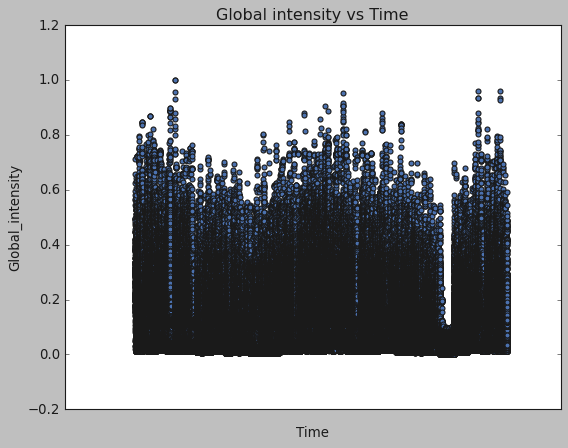

```python
df.plot.scatter(x='Index', y='Global_intensity', title= "Global intensity vs Time")
plt.tick_params(
    axis='x',          # changes apply to the x-axis
    which='both',      # both major and minor ticks are affected
    bottom=False,      # ticks along the bottom edge are off
    top=False,         # ticks along the top edge are off
    labelbottom=False) # labels along the bottom edge are off
plt.xlabel("Time", labelpad = 15)
plt.show(block=True);
```

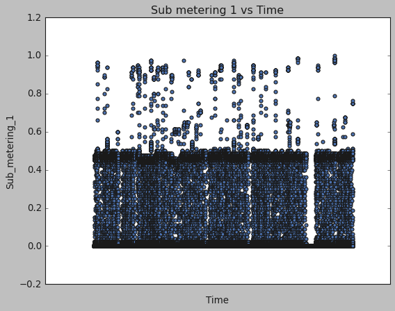

```python
df.plot.scatter(x='Index', y='Sub_metering_1', title= "Sub metering 1 vs Time")
plt.tick_params(
    axis='x',          # changes apply to the x-axis
    which='both',      # both major and minor ticks are affected
    bottom=False,      # ticks along the bottom edge are off
    top=False,         # ticks along the top edge are off
    labelbottom=False) # labels along the bottom edge are off
plt.xlabel("Time", labelpad = 15)
plt.show(block=True);
```

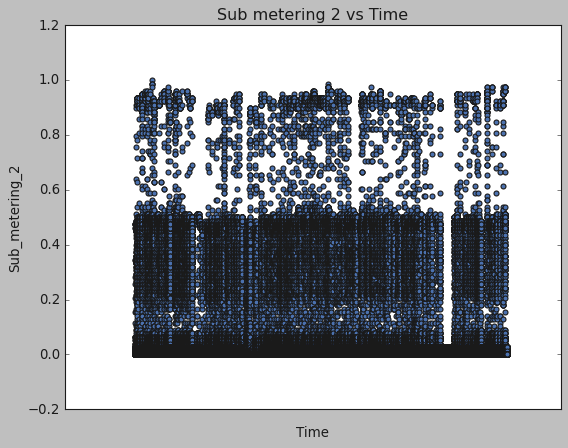

```python
df.plot.scatter(x='Index', y='Sub_metering_2', title= "Sub metering 2 vs Time")
plt.tick_params(
    axis='x',          # changes apply to the x-axis
    which='both',      # both major and minor ticks are affected
    bottom=False,      # ticks along the bottom edge are off
    top=False,         # ticks along the top edge are off
    labelbottom=False) # labels along the bottom edge are off
plt.xlabel("Time", labelpad = 15)
plt.show(block=True);
```

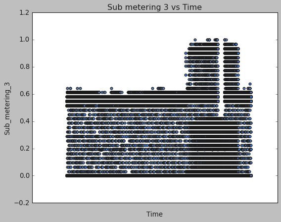

```python
df.plot.scatter(x='Index', y='Sub_metering_3', title= "Sub metering 3 vs Time")
plt.tick_params(
    axis='x',          # changes apply to the x-axis
    which='both',      # both major and minor ticks are affected
    bottom=False,      # ticks along the bottom edge are off
    top=False,         # ticks along the top edge are off
    labelbottom=False) # labels along the bottom edge are off
plt.xlabel("Time", labelpad = 15)
plt.show(block=True);
```

### Linear Regression

```python
df.info()
```

```
<class 'pandas.core.frame.DataFrame'>
RangeIndex: 1048575 entries, 0 to 1048574
Data columns (total 11 columns):
 #   Column                 Non-Null Count    Dtype
---  ------                 --------------    -----
 0   Global_active_power    1048575 non-null  float64
 1   Global_reactive_power  1048575 non-null  float64
 2   Voltage                1048575 non-null  float64
 3   Global_intensity       1048575 non-null  float64
 4   Sub_metering_1         1048575 non-null  float64
 5   Sub_metering_2         1048575 non-null  float64
 6   Sub_metering_3         1048575 non-null  float64
 7   Day                    1048575 non-null  float64
 8   Month                  1048575 non-null  float64
 9   Year                   1048575 non-null  float64
 10  Index                  1048575 non-null  int64
dtypes: float64(10), int64(1)
memory usage: 88.0 MB
```

### Preparing Data for Machine Learning

Category Indexing, One-Hot Encoding and VectorAssembler - a feature transformer that merges multiple columns into a vector column.

```python
from pyspark.ml.feature import OneHotEncoder, StringIndexer, VectorAssembler
from pyspark.ml.regression import LinearRegression

df_sp = spark.createDataFrame(df)
train, test = df_sp.randomSplit([0.7, 0.3])

assemblerInputs = ['Global_reactive_power', 'Voltage', 'Global_intensity',
               'Sub_metering_1', 'Sub_metering_2', 'Sub_metering_3']
assembler = VectorAssembler(inputCols=assemblerInputs, outputCol="features")

lr = LinearRegression(maxIter = 100, regParam = 0.3, elasticNetParam = 0.8,
                        featuresCol = 'features', labelCol = 'Global_active_power')
```

The above code are taken from databricks' official site.

The records in the dataset are ordered according to date and time and I have created a new column named "Index" to assign a number to each record.

Since the function randomSplit works for Spark dataframe, I have to convert my pandas dataframe back to Spark dataframe.

Next, we use the VectorAssembler to combine all the feature columns into a single vector column

### Pipeline

We use Pipeline to chain multiple Transformers and Estimators together to specify our machine learning workflow. A Pipeline’s stages are specified as an ordered array.

```python
from pyspark.ml import Pipeline
pl = Pipeline(stages = [assembler, lr])
mod = pl.fit(test) # use train --> see example code to confirm Prac8
```

### Linear Regression

```python
validation_train = test.randomSplit([0.1, 0.9])[0].select('Global_active_power', 'Global_reactive_power', 'Voltage', 'Global_intensity',
               'Sub_metering_1', 'Sub_metering_2', 'Sub_metering_3')
sample = mod.transform(validation_train)
```

```python
sample.toPandas()
```

|  | Global_active_power | Global_reactive_power | Voltage | Global_intensity | Sub_metering_1 | Sub_metering_2 | Sub_metering_3 | features | prediction |
| --- | --- | --- | --- | --- | --- | --- | --- | --- | --- |
| 0 | 0.002077 | 0.000000 | 0.450960 | 0.004329 | 0.0000 | 0.000000 | 0.000000 | (0.0, 0.45095986038394376, 0.00432900432900433... | 0.097643 |
| 1 | 0.002077 | 0.000000 | 0.527749 | 0.004329 | 0.0000 | 0.000000 | 0.000000 | (0.0, 0.5277486910994762, 0.00432900432900433,... | 0.097643 |
| 2 | 0.002265 | 0.000000 | 0.574520 | 0.004329 | 0.0000 | 0.000000 | 0.000000 | (0.0, 0.5745200698080266, 0.00432900432900433,... | 0.097643 |
| 3 | 0.002265 | 0.000000 | 0.643979 | 0.004329 | 0.0000 | 0.000000 | 0.000000 | (0.0, 0.6439790575916229, 0.00432900432900433,... | 0.097643 |
| 4 | 0.002265 | 0.000000 | 0.650960 | 0.004329 | 0.0000 | 0.000000 | 0.000000 | (0.0, 0.650959860383943, 0.00432900432900433, ... | 0.097643 |
| ... | ... | ... | ... | ... | ... | ... | ... | ... | ... |
| 31073 | 0.713611 | 0.211511 | 0.277138 | 0.709957 | 0.9625 | 0.000000 | 0.516129 | [0.21151079136690648, 0.2771378708551486, 0.70... | 0.097643 |
| 31074 | 0.720219 | 0.207194 | 0.311693 | 0.709957 | 0.9750 | 0.000000 | 0.548387 | [0.20719424460431654, 0.311692844677137, 0.709... | 0.097643 |
| 31075 | 0.723617 | 0.120863 | 0.387784 | 0.709957 | 0.9875 | 0.000000 | 0.548387 | [0.120863309352518, 0.3877835951134374, 0.7099... | 0.097643 |
| 31076 | 0.752501 | 0.073381 | 0.350436 | 0.744589 | 0.3250 | 0.461538 | 0.548387 | [0.07338129496402879, 0.3504363001745192, 0.74... | 0.097643 |
| 31077 | 0.964131 | 0.217266 | 0.258639 | 0.961039 | 0.4375 | 0.846154 | 0.548387 | [0.21726618705035972, 0.25863874345549664, 0.9... | 0.097643 |

31078 rows × 9 columns

See the table contains new columns named "features" and "prediction".

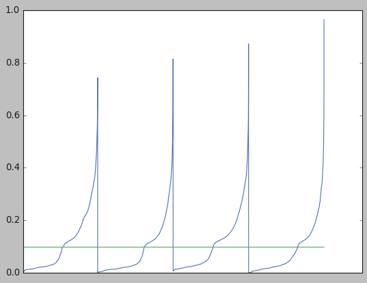

```python
plt.plot(validation_train.select("Global_active_power").toPandas())
plt.plot(sample.toPandas()['prediction'])
plt.tick_params(
    axis='x',          # changes apply to the x-axis
    which='both',      # both major and minor ticks are affected
    bottom=False,      # ticks along the bottom edge are off
    top=False,         # ticks along the top edge are off
    labelbottom=False) # labels along the bottom edge are off
```

Here, I have plot the prediction model and the real data of attribute "Global_active_power" to make comparison. It can be seen that the model deviates significantly from the real data, reflecting a severe inaccuracy and imprecision of the prediction model.

Evaluate our Regression model.

```python
from pyspark.ml.evaluation import RegressionEvaluator

evaluator = RegressionEvaluator(labelCol = 'Global_active_power',
                               predictionCol = 'prediction',
                               metricName = 'rmse')

trainingSummary = mod.stages[-1].summary
print("RMSE: %f" % trainingSummary.rootMeanSquaredError)
print("r2: %f" % trainingSummary.r2)
```

```
RMSE: 0.106699
r2: 0.000000
```

RMSE is a frequently used measure of the differences between values predicted by a model or an estimator and the values observed. It is the square root of the variance of the residuals. It indicates the absolute fit of the model to the data–how close the observed data points are to the model’s predicted values. Whereas R-squared is a relative measure of fit, RMSE is an absolute measure of fit. As the square root of a variance, RMSE can be interpreted as the standard deviation of the unexplained variance, and has the useful property of being in the same units as the response variable. Lower values of RMSE indicate better fit. RMSE is a good measure of how accurately the model predicts the response, and it is the most important criterion for fit if the main purpose of the model is prediction.

Decision trees are widely used since they are easy to interpret, handle categorical features, extend to the multiclass classification setting, do not require feature scaling, and are able to capture non-linearities and feature interactions.

```python
from pyspark.ml.regression import DecisionTreeRegressor
decTree = DecisionTreeRegressor(featuresCol = "features",
                              labelCol = 'Global_active_power')

decTree_pl = Pipeline(stages = [assembler, decTree])
decTree_mod = decTree_pl.fit(test)
```

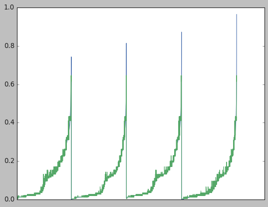

```python
plt.plot(validation_train.select("Global_active_power").toPandas())
plt.plot(decTree_mod.transform(validation_train).toPandas()['prediction'])
plt.tick_params(
    axis='x',          # changes apply to the x-axis
    which='both',      # both major and minor ticks are affected
    bottom=False,      # ticks along the bottom edge are off
    top=False,         # ticks along the top edge are off
    labelbottom=False) # labels along the bottom edge are off
```

Here, I have plot the prediction model and the real data of attribute "Global_active_power" to make comparison. It can be seen that the model seems to match the actual data.

Evaluate our Decision Tree model.

```python
from pyspark.ml.evaluation import RegressionEvaluator

evaluator_1 = RegressionEvaluator(labelCol = 'Global_active_power',
                               predictionCol = 'prediction',
                               metricName = 'rmse')

rmse = evaluator_1.evaluate(decTree_mod.transform(validation_train))

evaluator_2 = RegressionEvaluator(labelCol = 'Global_active_power',
                               predictionCol = 'prediction',
                               metricName = 'r2')

r2 = evaluator_2.evaluate(decTree_mod.transform(validation_train))


print("RMSE: " + str(rmse))
print("r2: " + str(r2))
```

```
RMSE: 0.012824648179079082
r2: 0.9854996727349279
```

### Random Forest Regression

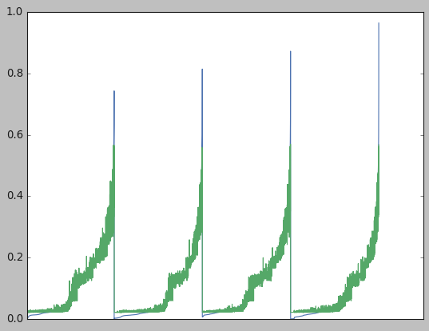

```python
from pyspark.ml.regression import RandomForestRegressor

rf = RandomForestRegressor(labelCol = 'Global_active_power', featuresCol="features")

randomFor = Pipeline(stages = [assembler, rf])
randomFor_mod = randomFor.fit(test)

plt.plot(validation_train.select("Global_active_power").toPandas())
plt.plot(randomFor_mod.transform(validation_train).toPandas()['prediction'])
plt.tick_params(
    axis='x',          # changes apply to the x-axis
    which='both',      # both major and minor ticks are affected
    bottom=False,      # ticks along the bottom edge are off
    top=False,         # ticks along the top edge are off
    labelbottom=False) # labels along the bottom edge are off
```

```python
evaluator_3 = RegressionEvaluator(labelCol = 'Global_active_power',
                               predictionCol = 'prediction',
                               metricName = 'rmse')

rmse = evaluator_2.evaluate(randomFor_mod.transform(validation_train))

evaluator_4 = RegressionEvaluator(labelCol = 'Global_active_power',
                               predictionCol = 'prediction',
                               metricName = 'rmse')

r2 = evaluator_4.evaluate(randomFor_mod.transform(validation_train))

print("RMSE: " + str(rmse))
print("r2: " + str(r2))
```

[output not shown]